# H2 Single Layer MLP

Bankbintje

22 februari 2016

# Data

## Load Data & Packages

Required packages worden geladen. Aanname is dat deze al voorkomen.

```r
library(neuralnet)
library(nnet)
library(plyr)
```

Install package “MixAll” en laad de dataset “DebTrivedi”. Check # rijen en kolommen. Beschrijving kolommen:

- ofp (number of physician office visits)
- hosp (number of hospital stays)
- health (self-perceived health status)
- numchron (number of chronic conditions)
- gender
- school (number of years of education)
- privins (private insurance indicator)

```r
##install.packages("MixAll")
data("DebTrivedi", package="MixAll")
data<-DebTrivedi
nrow(data)
```

```
## [1] 4406
```

```r
ncol(data)
```

```
## [1] 19
```

Verwijder data met NA’s, check # rijen en kolommen.

```r
data<-na.omit(data)
nrow(data)
```

```
## [1] 4406
```

```r
ncol(data)
```

```
## [1] 19
```

## Explore Data

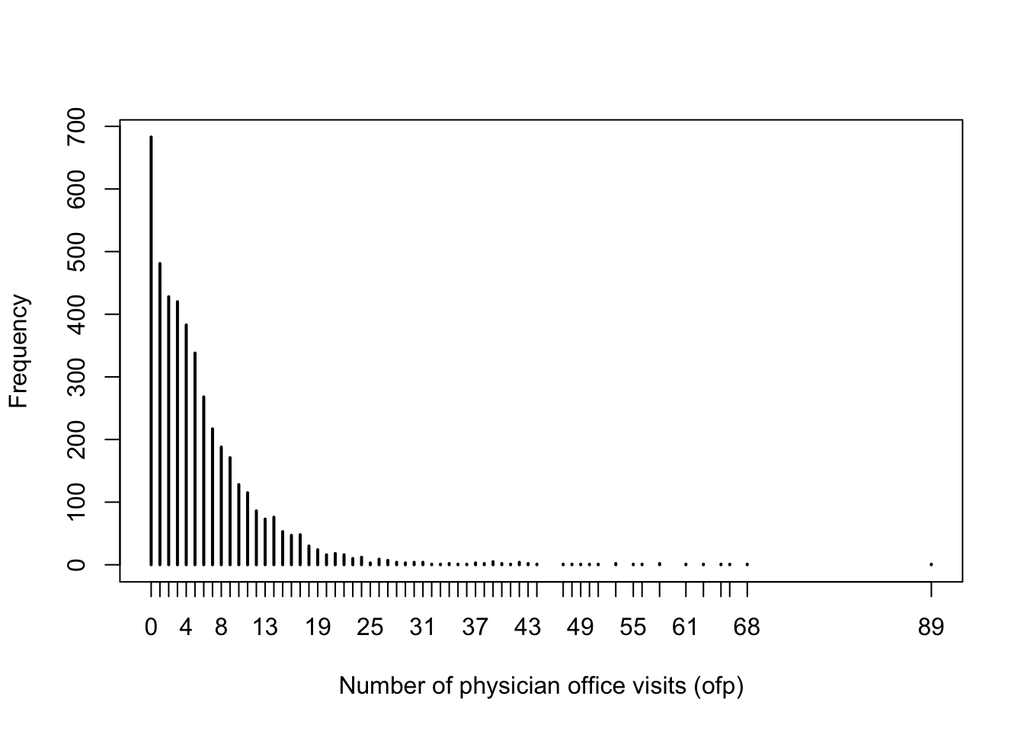

```r
plot(table(data$ofp), xlab= "Number of physician office visits (ofp)", ylab="Frequency")
```

```r
data$Class<- ifelse(DebTrivedi$ofp>=median(DebTrivedi$ofp),-1,1)
```

Check de verdeling

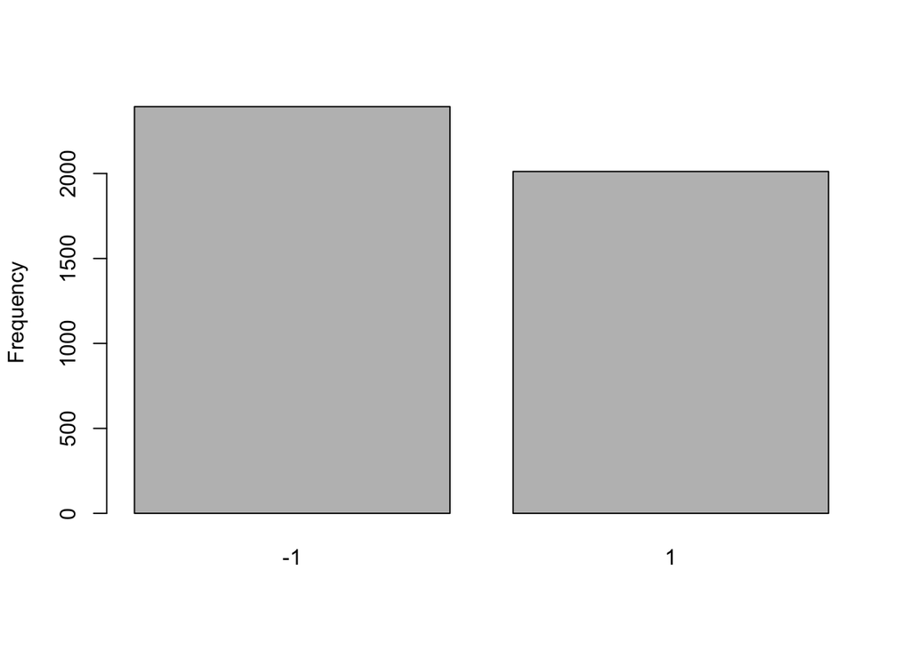

```r
barplot(table(data$Class), ylab = "Frequency")
```

Gebruik cfac function om relatie te tonen tussen “Class” en de covariates 1. hosp 2. health 3. numchron 4. gender 5. school 6. privins

uit https://cran.r-project.org/web/packages/pscl/vignettes/countreg.pdf

```r
cfac <- function (x, breaks = NULL){
if(is.null(breaks)) breaks <- unique(quantile(x, 0:10/10))
x <- cut(x,breaks,include.lowest=TRUE, right=FALSE)
levels(x) <- paste(breaks[-length(breaks)], ifelse(diff(breaks)>1,
c(paste("-", breaks[-c(1, length(breaks))] -1, sep = ""), "+"), ""),
sep = "") + return(x)}
```

Plot de data

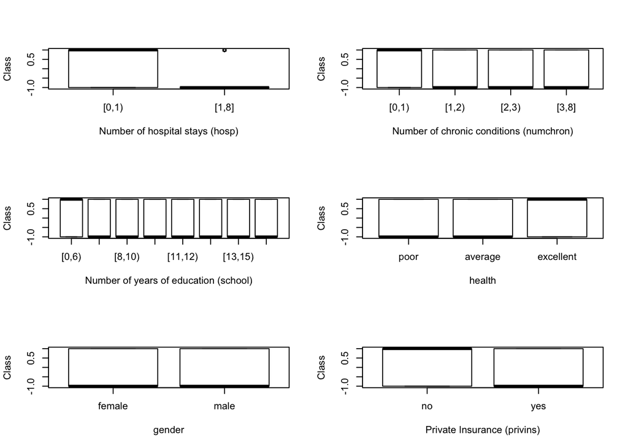

```r
par (mfrow = c(3,2))
plot (Class ~ cfac(hosp), data = data, xlab = "Number of hospital stays (hosp)")
plot (Class ~ cfac(numchron), data = data, xlab = "Number of chronic conditions (numchron)")
plot (Class ~ cfac(school), data = data, xlab = "Number of years of education (school)")
plot (Class ~ health, data = data)
plot (Class ~ gender, data = data)
plot (Class ~ privins, data = data, xlab = "Private Insurance (privins)")
```

## Prepare Data

Converteer gender, privins en health naar numerieke variabelen.

```r
levels(data$gender)<- c("-1","1")
data$gender<- as.numeric(as.character(data$gender))

levels(data$privins)<- c("-1","1")
data$privins<- as.numeric(as.character(data$privins))

levels(data$health)<- c("0","1","2")
data$health<- as.numeric(as.character(data$health))
```

Converteer overige variabelen naar numeriek

```r
data$hosp <- as.numeric(as.character(data$hosp))
data$numchron <- as.numeric(as.character(data$numchron))
data$school <- as.numeric(as.character(data$school))
```

Selecteer alleen relevante variabelen

```r
keeps<-c("Class", "hosp", "health", "numchron", "gender", "school", "privins")
data<-data[keeps]
head(data)
```

```
##   Class hosp health numchron gender school privins
## 1    -1    1      1        2      1      6       1
## 2     1    0      1        2     -1     10       1
## 3    -1    3      0        4     -1     10      -1
## 4    -1    1      0        2      1      3       1
## 5     1    0      1        2     -1      6       1
## 6    -1    0      0        5     -1      7      -1
```

Centreer data: subtract the mean of all data points from each individual data point.

```r
head(scale(data, center = TRUE, scale = FALSE))
```

```
##     Class       hosp      health  numchron     gender    school    privins
## 1 -0.9133  0.7040399  0.04788924 0.4580118  1.1929187 -4.290286  0.4471176
## 2  1.0867 -0.2959601  0.04788924 0.4580118 -0.8070813 -0.290286  0.4471176
## 3 -0.9133  2.7040399 -0.95211076 2.4580118 -0.8070813 -0.290286 -1.5528824
## 4 -0.9133  0.7040399 -0.95211076 0.4580118  1.1929187 -7.290286  0.4471176
## 5  1.0867 -0.2959601  0.04788924 0.4580118 -0.8070813 -4.290286  0.4471176
## 6 -0.9133 -0.2959601 -0.95211076 3.4580118 -0.8070813 -3.290286 -1.5528824
```

Standardiseer (center & scale) de data met scale: subtract the mean of all data points from each individual data point, then divide those points by the standard deviation of all points.

```r
data<-scale(data)
head(data)
```

```
##        Class       hosp     health  numchron     gender      school
## 1 -0.9166481  0.9432503  0.1067271 0.3393606  1.2156191 -1.14752323
## 2  1.0906836 -0.3965179  0.1067271 0.3393606 -0.8224394 -0.07764282
## 3 -0.9166481  3.6227866 -2.1218967 1.8212464 -0.8224394 -0.07764282
## 4 -0.9166481  0.9432503 -2.1218967 0.3393606  1.2156191 -1.94993354
## 5  1.0906836 -0.3965179  0.1067271 0.3393606 -0.8224394 -1.14752323
## 6 -0.9166481 -0.3965179 -2.1218967 2.5621893 -0.8224394 -0.88005313
##      privins
## 1  0.5365279
## 2  0.5365279
## 3 -1.8634130
## 4  0.5365279
## 5  0.5365279
## 6 -1.8634130
```

## Correlation Plots

Maak een standaard corrplot van de dataset

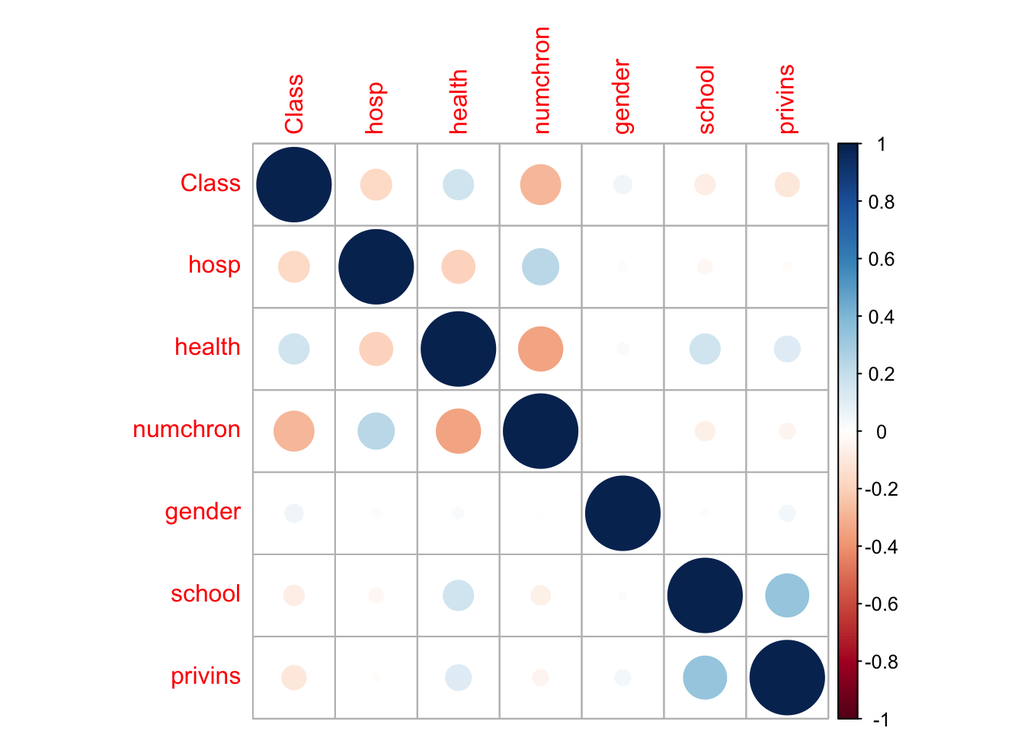

```r
library(corrplot)
corrplot(cor(data))
```

Functie voor het bepalen van correlatie & significantie

```r
cor.mtest <- function(mat, conf.level = 0.95) {
    mat <- as.matrix(mat)
    n <- ncol(mat)
    p.mat <- lowCI.mat <- uppCI.mat <- matrix(NA, n, n)
    diag(p.mat) <- 0
    diag(lowCI.mat) <- diag(uppCI.mat) <- 1
    for (i in 1:(n - 1)) {
        for (j in (i + 1):n) {
            tmp <- cor.test(mat[, i], mat[, j], conf.level = conf.level)
            p.mat[i, j] <- p.mat[j, i] <- tmp$p.value
            lowCI.mat[i, j] <- lowCI.mat[j, i] <- tmp$conf.int[1]
            uppCI.mat[i, j] <- uppCI.mat[j, i] <- tmp$conf.int[2]
        }
    }
    return(list(p.mat, lowCI.mat, uppCI.mat))
}
```

Verschillende manieren om correlatie te plotten. Zie: https://cran.r-project.org/web/packages/corrplot/vignettes/corrplot-intro.html

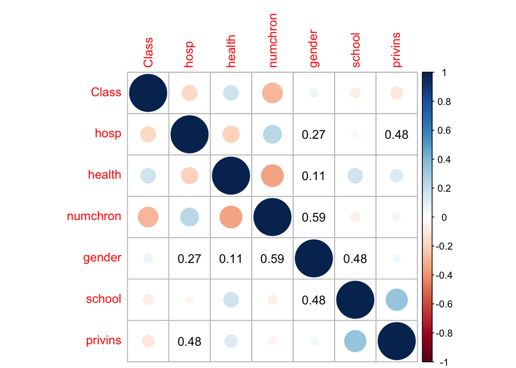

```r
res<-cor.mtest(data)
## add p-values on no significant coefficient
corrplot(cor(data), p.mat = res[[1]], sig.level = 0.1,insig="p-value")
```

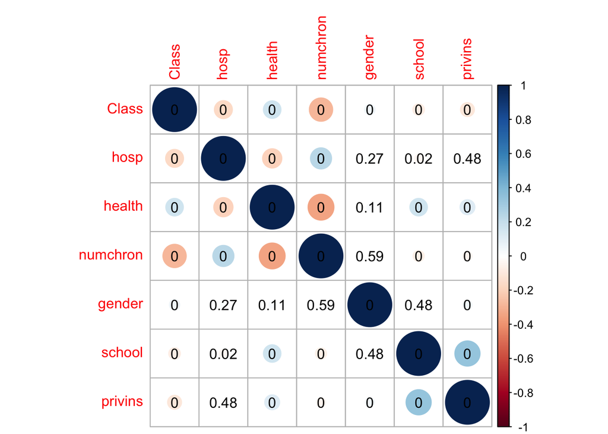

```r
## add all p-values
corrplot(cor(data), p.mat = res[[1]], sig.level = -1,insig="p-value")
```

# Neural Network

## Preparations

Schrijf de formule eerst als variabele:

```r
f<-Class ~ hosp + health + numchron + gender + school + privins
# seed
set.seed(103)
n=nrow(data)
# selecteer trainingset
train <- sample(1:n, 4000, FALSE)
```

## Estimate the model

Maak een MLP met een hidden layer

```r
fit <- neuralnet(f, data = data[train,], hidden = 1, algorithm = "rprop+",
                 err.fct = "sse", act.fct = "logistic",
                 linear.output = FALSE)
```

## Results

```r
print(fit)
```

```
## Call: neuralnet(formula = f, data = data[train, ], hidden = 1, algorithm = "rprop+",     err.fct = "sse", act.fct = "logistic", linear.output = FALSE)
##
## 1 repetition was calculated.
##
##         Error Reached Threshold Steps
## 1 1854.659153    0.008971185555 15376
```

https://groups.google.com/forum/#!topic/rropen/qS7Fki9pj8k

```r
plotnn <- function (x, rep = NULL, x.entry = NULL, x.out = NULL, radius = 0.15,
  arrow.length = 0.2, intercept = TRUE, intercept.factor = 0.4,
  information = TRUE, information.pos = 0.1, col.entry.synapse = "black",
  col.entry = "black", col.hidden = "black", col.hidden.synapse = "black",
  col.out = "black", col.out.synapse = "black", col.intercept = "blue",
  fontsize = 12, dimension = 6, show.weights = TRUE, file = NULL,
  ...)
{
  net <- x
  if (is.null(net$weights))
    stop("weights were not calculated")
  if (!is.null(file) && !is.character(file))
    stop("'file' must be a string")
  if (is.null(rep)) {
    for (i in 1:length(net$weights)) {
      if (!is.null(file))
        file.rep <- paste(file, ".", i, sep = "")
      else file.rep <- NULL
      # dev.new()
      plot.nn(net, rep = i, x.entry, x.out, radius, arrow.length,
        intercept, intercept.factor, information, information.pos,
        col.entry.synapse, col.entry, col.hidden, col.hidden.synapse,
        col.out, col.out.synapse, col.intercept, fontsize,
        dimension, show.weights, file.rep, ...)
    }
  }
  else {
    if (is.character(file) && file.exists(file))
      stop(sprintf("%s already exists", sQuote(file)))
    result.matrix <- t(net$result.matrix)
    if (rep == "best")
      rep <- as.integer(which.min(result.matrix[, "error"]))
    if (rep > length(net$weights))
      stop("'rep' does not exist")
    weights <- net$weights[[rep]]
    if (is.null(x.entry))
      x.entry <- 0.5 - (arrow.length/2) * length(weights)
    if (is.null(x.out))
      x.out <- 0.5 + (arrow.length/2) * length(weights)
    width <- max(x.out - x.entry + 0.2, 0.8) * 8
    radius <- radius/dimension
    entry.label <- net$model.list$variables
    out.label <- net$model.list$response
    neuron.count <- array(0, length(weights) + 1)
    neuron.count[1] <- nrow(weights[[1]]) - 1
    neuron.count[2] <- ncol(weights[[1]])
    x.position <- array(0, length(weights) + 1)
    x.position[1] <- x.entry
    x.position[length(weights) + 1] <- x.out
    if (length(weights) > 1)
      for (i in 2:length(weights)) {
        neuron.count[i + 1] <- ncol(weights[[i]])
        x.position[i] <- x.entry + (i - 1) * (x.out -
          x.entry)/length(weights)
      }
    y.step <- 1/(neuron.count + 1)
    y.position <- array(0, length(weights) + 1)
    y.intercept <- 1 - 2 * radius
    information.pos <- min(min(y.step) - 0.1, 0.2)
    if (length(entry.label) != neuron.count[1]) {
      if (length(entry.label) < neuron.count[1]) {
        tmp <- NULL
        for (i in 1:(neuron.count[1] - length(entry.label))) {
          tmp <- c(tmp, "no name")
        }
        entry.label <- c(entry.label, tmp)
      }
    }
    if (length(out.label) != neuron.count[length(neuron.count)]) {
      if (length(out.label) < neuron.count[length(neuron.count)]) {
        tmp <- NULL
        for (i in 1:(neuron.count[length(neuron.count)] -
          length(out.label))) {
          tmp <- c(tmp, "no name")
        }
        out.label <- c(out.label, tmp)
      }
    }
    grid.newpage()
    for (k in 1:length(weights)) {
      for (i in 1:neuron.count[k]) {
        y.position[k] <- y.position[k] + y.step[k]
        y.tmp <- 0
        for (j in 1:neuron.count[k + 1]) {
          y.tmp <- y.tmp + y.step[k + 1]
          result <- calculate.delta(c(x.position[k],
            x.position[k + 1]), c(y.position[k], y.tmp),
            radius)
          x <- c(x.position[k], x.position[k + 1] -
            result[1])
          y <- c(y.position[k], y.tmp + result[2])
          grid.lines(x = x, y = y, arrow = arrow(length = unit(0.15,
            "cm"), type = "closed"), gp = gpar(fill = col.hidden.synapse,
            col = col.hidden.synapse, ...))
          if (show.weights)
            draw.text(label = weights[[k]][neuron.count[k] -
              i + 2, neuron.count[k + 1] - j + 1], x = c(x.position[k],
              x.position[k + 1]), y = c(y.position[k],
              y.tmp), xy.null = 1.25 * result, color = col.hidden.synapse,
              fontsize = fontsize - 2, ...)
        }
        if (k == 1) {
          grid.lines(x = c((x.position[1] - arrow.length),
            x.position[1] - radius), y = y.position[k],
            arrow = arrow(length = unit(0.15, "cm"),
              type = "closed"), gp = gpar(fill = col.entry.synapse,
              col = col.entry.synapse, ...))
          draw.text(label = entry.label[(neuron.count[1] +
            1) - i], x = c((x.position - arrow.length),
            x.position[1] - radius), y = c(y.position[k],
            y.position[k]), xy.null = c(0, 0), color = col.entry.synapse,
            fontsize = fontsize, ...)
          grid.circle(x = x.position[k], y = y.position[k],
            r = radius, gp = gpar(fill = "white", col = col.entry,
              ...))
        }
        else {
          grid.circle(x = x.position[k], y = y.position[k],
            r = radius, gp = gpar(fill = "white", col = col.hidden,
              ...))
        }
      }
    }
    out <- length(neuron.count)
    for (i in 1:neuron.count[out]) {
      y.position[out] <- y.position[out] + y.step[out]
      grid.lines(x = c(x.position[out] + radius, x.position[out] +
        arrow.length), y = y.position[out], arrow = arrow(length = unit(0.15,
        "cm"), type = "closed"), gp = gpar(fill = col.out.synapse,
        col = col.out.synapse, ...))
      draw.text(label = out.label[(neuron.count[out] +
        1) - i], x = c((x.position[out] + radius), x.position[out] +
        arrow.length), y = c(y.position[out], y.position[out]),
        xy.null = c(0, 0), color = col.out.synapse,
        fontsize = fontsize, ...)
      grid.circle(x = x.position[out], y = y.position[out],
        r = radius, gp = gpar(fill = "white", col = col.out,
          ...))
    }
    if (intercept) {
      for (k in 1:length(weights)) {
        y.tmp <- 0
        x.intercept <- (x.position[k + 1] - x.position[k]) *
          intercept.factor + x.position[k]
        for (i in 1:neuron.count[k + 1]) {
          y.tmp <- y.tmp + y.step[k + 1]
          result <- calculate.delta(c(x.intercept, x.position[k +
            1]), c(y.intercept, y.tmp), radius)
          x <- c(x.intercept, x.position[k + 1] - result[1])
          y <- c(y.intercept, y.tmp + result[2])
          grid.lines(x = x, y = y, arrow = arrow(length = unit(0.15,
            "cm"), type = "closed"), gp = gpar(fill = col.intercept,
            col = col.intercept, ...))
          xy.null <- cbind(x.position[k + 1] - x.intercept -
            2 * result[1], -(y.tmp - y.intercept + 2 *
            result[2]))
          if (show.weights)
            draw.text(label = weights[[k]][1, neuron.count[k +
              1] - i + 1], x = c(x.intercept, x.position[k +
              1]), y = c(y.intercept, y.tmp), xy.null = xy.null,
              color = col.intercept, alignment = c("right",
                "bottom"), fontsize = fontsize - 2,
              ...)
        }
        grid.circle(x = x.intercept, y = y.intercept,
          r = radius, gp = gpar(fill = "white", col = col.intercept,
            ...))
        grid.text(1, x = x.intercept, y = y.intercept,
          gp = gpar(col = col.intercept, ...))
      }
    }
    if (information)
      grid.text(paste("Error: ", round(result.matrix[rep,
        "error"], 6), "   Steps: ", result.matrix[rep,
        "steps"], sep = ""), x = 0.5, y = information.pos,
        just = "bottom", gp = gpar(fontsize = fontsize +
          2, ...))
    if (!is.null(file)) {
      weight.plot <- recordPlot()
      save(weight.plot, file = file)
    }
  }
}
```

Simple plot, intercept & weights are turned off.

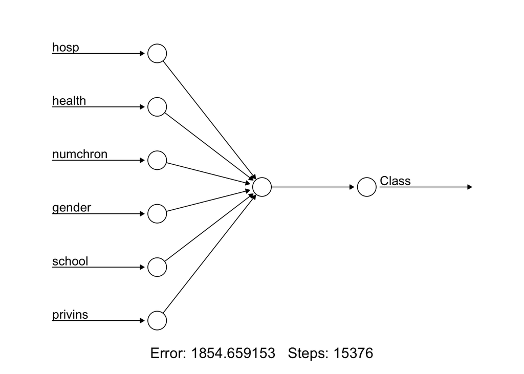

```r
##par (mfrow = c(1,1))
plotnn(fit, intercept = FALSE, show.weights = FALSE)
```

To see what `fit` actually contains, run:

```r
attributes(fit)
```

```
## $names
##  [1] "call"                "response"            "covariate"
##  [4] "model.list"          "err.fct"             "act.fct"
##  [7] "linear.output"       "data"                "net.result"
## [10] "weights"             "startweights"        "generalized.weights"
## [13] "result.matrix"
##
## $class
## [1] "nn"
```

To check details of a particular attribute, use the `$` operator. For example, check the summary of the fitted network contained in `result.matrix`:

```r
fit$result.matrix
```

```
##                                        1
## error                  1854.659153417289
## reached.threshold         0.008971185555
## steps                 15376.000000000000
## Intercept.to.1layhid1    -1.476505618519
## hosp.to.1layhid1          0.936995772797
## health.to.1layhid1       -0.308589104362
## numchron.to.1layhid1      1.065004008360
## gender.to.1layhid1       -0.190692443760
## school.to.1layhid1        0.159883623634
## privins.to.1layhid1       0.363787899579
## Intercept.to.Class        1.648630276189
## 1layhid.1.to.Class      -40.196940113888
```

The value goven for `hosp.to.1layhid1` is the calculated optimum weight of the synapse between `hosp` and the hidden neuron.

## Predicting new cases

Method `compute` from the neuralnet package computes the output of all neurons given a trained neural network using (the same!) covariate vectors.

```r
pred<-compute(fit, data[-train, 2:7])
```

View the first few predictions from $net.result

```r
## show attributes in pred
attributes(pred)
```

```
## $names
## [1] "neurons"    "net.result"
```

```r
## get top results
head(pred$net.result)
```

```
##                    [,1]
## 1  0.000001149730617861
## 15 0.000004387003430401
## 16 0.666976073629486299
## 46 0.000000001263003749
## 76 0.000000469604180798
## 82 0.000217696667194658
```

These numbers give the probability of an individual belonging to the below median or above median. Let’s convert them back to the same -1, +1 scale as used in `Class`.

```r
r2 <- ifelse(pred$net.result<=0.5,-1,1)
head(r2)
```

```
##    [,1]
## 1    -1
## 15   -1
## 16    1
## 46   -1
## 76   -1
## 82   -1
```

## Check Results

Build a confusion matrix:

```r
table(sign(r2), sign(data[-train,1]), dnn=c("Predicted", "Observed"))
```

```
##          Observed
## Predicted  -1   1
##        -1 205 157
##        1   11  33
```

Of the 406 observations 205 were correctlt classified as belonging to group -1, and 33 were correctly classified as belonging to group +1. The error rate is calculated measuring the misclassified observations as proportion of the total:

```r
error_rate = (1- sum(sign(r2)==sign(data[-train,1]))/length(data[-train,1]))
round(error_rate, 2)
```

```
## [1] 0.41
```

Overall 41% of individuals were misclassified. This implies a prediction accuray of around 59%.

Nog beter: gebruik caret

```r
library(caret)
confusionMatrix(data=r2,reference = sign(data[-train,1]) )
```

```
## Confusion Matrix and Statistics
##
##           Reference
## Prediction  -1   1
##         -1 205 157
##         1   11  33
##
##                Accuracy : 0.5862069
##                  95% CI : (0.536584, 0.6345639)
##     No Information Rate : 0.5320197
##     P-Value [Acc > NIR] : 0.01602206
##
##                   Kappa : 0.1287108
##  Mcnemar's Test P-Value : < 0.000000000000000222
##
##             Sensitivity : 0.9490741
##             Specificity : 0.1736842
##          Pos Pred Value : 0.5662983
##          Neg Pred Value : 0.7500000
##              Prevalence : 0.5320197
##          Detection Rate : 0.5049261
##    Detection Prevalence : 0.8916256
##       Balanced Accuracy : 0.5613791
##
##        'Positive' Class : -1
##
```

# Excercises

## Question 1

Re-build the model, but this time using six hidden nodes

```r
set.seed(103)
fit.q1 <- neuralnet(f, data = data[train,], hidden = 6, algorithm = "rprop+",
                 err.fct = "sse", act.fct = "logistic",
                 linear.output = FALSE)
```

### Q1 Results

```r
print(fit.q1)
```

```
## Call: neuralnet(formula = f, data = data[train, ], hidden = 6, algorithm = "rprop+",     err.fct = "sse", act.fct = "logistic", linear.output = FALSE)
##
## 1 repetition was calculated.
##
##         Error Reached Threshold Steps
## 1 1828.890459    0.009396198984  3698
```

The model converged after 3.698 steps with an error of 1829.

Simple plot, intercept & weights are turned off.

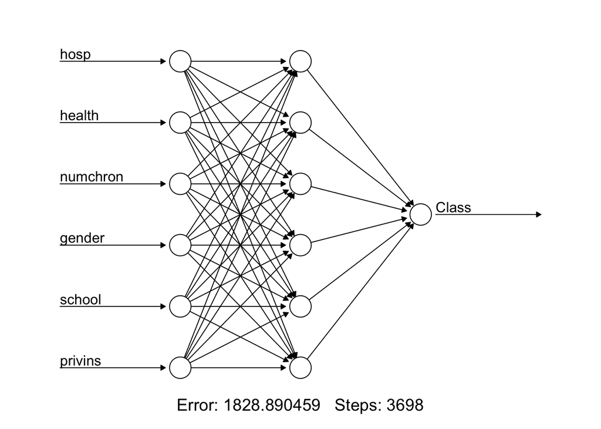

```r
plotnn(fit.q1, intercept = FALSE, show.weights = FALSE)
```

To check details of a particular attribute, use the `$` operator. For example, check the summary of the fitted network contained in `result.matrix`:

```r
fit.q1$result.matrix
```

```
##                                       1
## error                 1828.890458758729
## reached.threshold        0.009396198984
## steps                 3698.000000000000
## Intercept.to.1layhid1   -0.423447092047
## hosp.to.1layhid1        25.652913369638
## health.to.1layhid1     -29.078245640452
## numchron.to.1layhid1    35.197525071508
## gender.to.1layhid1      -8.269092230283
## school.to.1layhid1     -11.301181730922
## privins.to.1layhid1     13.546659283759
## Intercept.to.1layhid2    6.935431125606
## hosp.to.1layhid2        -4.496416358485
## health.to.1layhid2      -8.027431561327
## numchron.to.1layhid2    -0.446288483916
## gender.to.1layhid2       4.023964410207
## school.to.1layhid2      -1.325467311502
## privins.to.1layhid2      8.635792296373
## Intercept.to.1layhid3   -0.255934305279
## hosp.to.1layhid3        15.742935399865
## health.to.1layhid3       3.988391663041
## numchron.to.1layhid3    39.842999489774
## gender.to.1layhid3       2.926658697943
## school.to.1layhid3      16.803364678757
## privins.to.1layhid3      9.332931392087
## Intercept.to.1layhid4   -0.115168770514
## hosp.to.1layhid4       -33.404504874158
## health.to.1layhid4     -16.018131378684
## numchron.to.1layhid4   -63.848494692455
## gender.to.1layhid4       0.275023894060
## school.to.1layhid4     -15.231794136035
## privins.to.1layhid4    -30.010214935539
## Intercept.to.1layhid5    2.897128715511
## hosp.to.1layhid5         0.751106103924
## health.to.1layhid5      -5.131686199332
## numchron.to.1layhid5     2.627657202005
## gender.to.1layhid5      -0.752776696962
## school.to.1layhid5       0.512525226472
## privins.to.1layhid5     -0.864357341599
## Intercept.to.1layhid6   -8.017062403861
## hosp.to.1layhid6        40.598224383093
## health.to.1layhid6      12.401076005280
## numchron.to.1layhid6    27.942416386952
## gender.to.1layhid6      -2.669361683444
## school.to.1layhid6      27.402140833438
## privins.to.1layhid6     29.260771923642
## Intercept.to.Class      -0.985088675130
## 1layhid.1.to.Class    -252.166172075793
## 1layhid.2.to.Class      -2.479937906277
## 1layhid.3.to.Class    -245.656856629309
## 1layhid.4.to.Class       3.940218969832
## 1layhid.5.to.Class      -3.441144063418
## 1layhid.6.to.Class      -2.957627410226
```

## Q1 Predicting new cases

Method `compute` from the neuralnet package computes the output of all neurons given a trained neural network using (the same!) covariate vectors.

```r
pred.q1<-compute(fit.q1, data[-train, 2:7])
```

These numbers give the probability of an individual belonging to the below median or above median. Let’s convert them back to the same -1, +1 scale as used in `Class`.

```r
r2.q1 <- ifelse(pred.q1$net.result<=0.5,-1,1)
head(r2.q1)
```

```
##    [,1]
## 1    -1
## 15   -1
## 16    1
## 46   -1
## 76   -1
## 82   -1
```

### Check Results Q1

Build a confusion matrix:

```r
table(sign(r2.q1), sign(data[-train,1]), dnn=c("Predicted", "Observed"))
```

```
##          Observed
## Predicted  -1   1
##        -1 203 158
##        1   13  32
```

```r
error_rate.q1 = (1- sum(sign(r2.q1)==sign(data[-train,1]))/length(data[-train,1]))
round(error_rate.q1, 2)
```

```
## [1] 0.42
```

Overall 42% of individuals were misclassified. This implies a prediction accuray of around 58%. Nog beter: gebruik caret

```r
library(caret)
confusionMatrix(data=r2.q1,reference = sign(data[-train,1]) )
```

```
## Confusion Matrix and Statistics
##
##           Reference
## Prediction  -1   1
##         -1 203 158
##         1   13  32
##
##                Accuracy : 0.5788177
##                  95% CI : (0.5291297, 0.6273485)
##     No Information Rate : 0.5320197
##     P-Value [Acc > NIR] : 0.03262661
##
##                   Kappa : 0.1134466
##  Mcnemar's Test P-Value : < 0.000000000000000222
##
##             Sensitivity : 0.9398148
##             Specificity : 0.1684211
##          Pos Pred Value : 0.5623269
##          Neg Pred Value : 0.7111111
##              Prevalence : 0.5320197
##          Detection Rate : 0.5000000
##    Detection Prevalence : 0.8891626
##       Balanced Accuracy : 0.5541179
##
##        'Positive' Class : -1
##
```